# Assignment 1

Molly Richard

29-Aug-2019

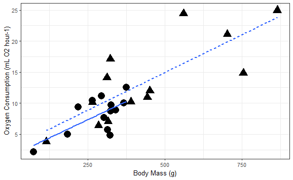

```r
ggplot(SMR, aes(x= Mass , y= Average_MR , shape=Sex, lty = Sex))+
  geom_point(aes(size = 2))+
  geom_smooth(method=(lm), se= FALSE)+
  xlab("Body Mass (g)") + ylab("Oxygen Consumption (mL O2 hour-1)")+
  theme_bw(base_size = 10)+
  theme(legend.position = "none")
```

**Graph 1.** Shows the relationship between mass and standard metabolic rate in male and female cottonmouths, *Agkistrodon piscivorus*.

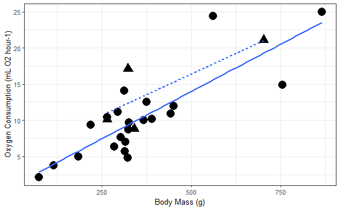

```r
ggplot(SMR, aes(x= Mass , y= Average_MR, shape=Shedding, lty = Shedding))+
  geom_point(aes(size = 2))+
  geom_smooth(method=(lm), se = FALSE)+
  xlab("Body Mass (g)") + ylab("Oxygen Consumption (mL O2 hour-1)")+
  theme_bw(base_size = 10)+
  theme(legend.position = "none")
```

**Graph 2.** Depicts that energetic costs of shedding in individual cottonmouths.

An ancova was used to determine there is no significant difference between shedding and non-shedding individual’s metabolic rate when accounting for mass. (p=0.142, r<sup>2</sup>=0.6757, F-stat = 27.04, df=2,23)

```r
Shed_SMR <- lm(Average_MR ~ Mass + Shedding, data = SMR)
Shed_anova <- anova(Shed_SMR)
summary(Shed_SMR)
```

```
Call:
lm(formula = Average_MR ~ Mass + Shedding, data = SMR)

Residuals:
    Min      1Q  Median      3Q     Max
-5.5995 -1.4563 -0.7118  1.7836  8.9378

Coefficients:
            Estimate Std. Error t value Pr(>|t|)
(Intercept) 1.091664   1.486868   0.734    0.470
Mass        0.025677   0.003667   7.003 3.89e-07 ***
SheddingYes 2.736127   1.801542   1.519    0.142
---
Signif. codes:  0 â€˜***â€™ 0.001 â€˜**â€™ 0.01 â€˜*â€™ 0.05 â€˜.â€™ 0.1 â€˜ â€™ 1

Residual standard error: 3.297 on 23 degrees of freedom
Multiple R-squared:  0.7016,    Adjusted R-squared:  0.6757
F-statistic: 27.04 on 2 and 23 DF,  p-value: 9.12e-07
```

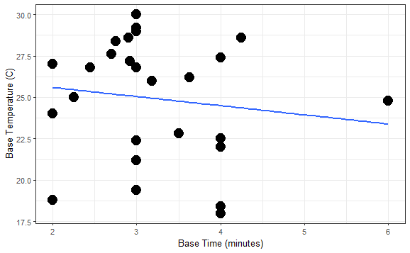

```r
ggplot(SMR, aes(x= Basetime , y= BaseTemp))+
  geom_point(aes(size = 2))+
  geom_smooth(method=(lm), se= FALSE)+
  xlab("Base Time (minutes)") + ylab("Base Temperature (C)")+
  theme_bw(base_size = 10)+
  theme(legend.position = "none")
```

**Graph 3** shows the Base Time which is the time to draw a blood sample after capture, and the associated temperature at the time collection.

The statistical summary below shows that there is no significant relationship between the time to blood after capture and the cloacal temperature at the time of blood aquisition.

```r
blood <- lm(BaseTemp ~ Basetime, data = SMR)
blood_anova <- anova(blood)
summary(blood)
```

```
Call:
lm(formula = BaseTemp ~ Basetime, data = SMR)

Residuals:
   Min     1Q Median     3Q    Max
-6.795 -2.368  1.407  2.778  4.956

Coefficients:
            Estimate Std. Error t value Pr(>|t|)
(Intercept)  26.6958     2.8005   9.533 1.24e-09 ***
Basetime     -0.5506     0.8422  -0.654     0.52
---
Signif. codes:  0 â€˜***â€™ 0.001 â€˜**â€™ 0.01 â€˜*â€™ 0.05 â€˜.â€™ 0.1 â€˜ â€™ 1

Residual standard error: 3.681 on 24 degrees of freedom
Multiple R-squared:  0.01749,   Adjusted R-squared:  -0.02344
F-statistic: 0.4273 on 1 and 24 DF,  p-value: 0.5195
```

The summary below gives a snap shot of the first 15 rows of data used in the graphs depicted.

```r
kable(SMR[1:15, ], format = "pandoc", caption = '<strong>Table 1.</strong>  A knitr table depicting the first 15 rows of data found in the SMR dataset.')
```

**Table 1.** A knitr table depicting the first 15 rows of data found in the SMR dataset.

| Date Captured | Pit tag | Mass | Sex | Shedding | Average_MR | Latitude | Longitude | Basetime | BaseTemp |
| --- | --- | --- | --- | --- | --- | --- | --- | --- | --- |
| 8-May-19 | 985 120021029846 | 560 | M | No | 24.40880 | 36.29178 | -87.09822 | 4.00 | 22.5 |
| 12-May-19 | 985 121019060692 | 184 | F | No | 4.96754 | 36.29178 | -87.09871 | 3.00 | 19.4 |
| 12-May-19 | 5006592966 | 303 | F | No | 7.67954 | 36.29199 | -87.09774 | 4.00 | 18.4 |
| 13-May-19 | 50065A484C | 323 | M | Yes | 17.10700 | 36.29189 | -87.09975 | 2.00 | 18.8 |
| 14-May-19 | 500655460C | 295 | F | No | 11.14678 | 36.29108 | -87.09803 | 4.00 | 22.0 |
| 14-May-19 | 502C047745 | 702 | M | Yes | 21.06080 | 36.29178 | -87.09968 | 4.00 | 18.0 |
| 15-May-19 | 5006693B57 | 367 | F | No | 9.98248 | 36.29259 | -87.10020 | 2.00 | 24.0 |
| 15-May-19 | 50065E515B | 265 | M | Yes | 10.14286 | 36.29245 | -87.09999 | 3.00 | 21.2 |
| 22-May-19 | 50066A6D0D | 74 | F | No | 2.17621 | 36.29153 | -87.09788 | 3.00 | 30.0 |
| 22-May-19 | 500664104A | 266 | F | No | 10.41448 | 36.29178 | -87.09968 | 2.00 | 27.0 |
| 27-May-19 | 5006591E 16 | 219 | F | No | 9.40648 | 36.29234 | -87.09807 | 2.75 | 28.4 |
| 5-Jun-19 | 503342193E | 375 | F | No | 12.54018 | 36.29278 | -87.10030 | 3.00 | 29.2 |
| 5-Jun-19 | 500657657F | 443 | M | No | 10.92242 | 36.29288 | -87.09991 | 3.00 | 29.0 |
| 8-Jun-19 | 50333B3316 | 864 | M | No | 24.95280 | 36.29299 | -87.10045 | 4.00 | 27.4 |
| 8-Jun-19 | 985 153000295440 | 340 | F | Yes | 8.85460 | 36.29305 | -87.10045 | 6.00 | 24.8 |

### Summary table of statistics

Table 2 and 3 depicts summary data of the average metabolic rates and average blood draw time of all cottonmouths, and the standard deviations between individuals and between times

```r
SMRsummary <- summarise(group_by(SMR),
                      n=n(),
                      mean=mean(Average_MR),
                      sd=sd(Mass))
kable(SMRsummary, format = "pandoc", caption = '<strong>Table 2.</strong>  A summary table displaying the number of snakes captured, the average metabolic rate, and standard deviation of mass.')
```

**Table 2.** A summary table displaying the number of snakes captured, the average metabolic rate, and standard deviation of mass.

| n | mean | sd |
| --- | --- | --- |
| 26 | 10.88583 | 180.776 |

```r
SMRsummary <- summarise(group_by(SMR),
                      n=n(),
                      mean=mean(Basetime),
                      sd=sd(Basetime))
kable(SMRsummary, format = "pandoc", caption = '<strong>Table 3.</strong>  Depicts the average time to draw blood and the standard deviation between draw times.')
```

**Table 3.** Depicts the average time to draw blood and the standard deviation between draw times.

| n | mean | sd |
| --- | --- | --- |
| 26 | 3.212692 | 0.8740598 |

### Map of Capture Locations

This interactive map shows the capture location of the 26 snakes captured in 2019.

```r
leaflet(data=SMR) %>%
    addTiles() %>%
      addMarkers(data = SMR, lat = ~Latitude, lng = ~Longitude)
```

[interactive chart not shown]